# Lab: Analyze Business Needs and Prepare Patient Data

**==============================================================**

Task 1: Review and load the datasets

Objective

Familiarize yourself with the raw data before cleaning or transforming it

Step 1: Open the data sheets

Open Microsoft Excel and load the Patient Data and Appointment Data sheets provided

Step 2: Review the Patient_Data sheet

Scan the sheet to get familiar with the columns such as PatientID, Email, DateOfBirth, OutstandingBalance, etc.

```
Look for:
    Inconsistent date formats
    Blank fields (especially in Email or DateOfBirth)
    Unusual values such as negative balances or non-standard location names
```

Step 3: Review the Appointment_Data sheet

```
Check for columns such as AppointmentID, AppointmentDate, ClinicLocation, and AppointmentFee
Look for:
    Currency symbols or non-numeric entries in the AppointmentFee column
    Duplicate appointment IDs
    Blank or inconsistent AppointmentDate values
```

**===========================================**

## Import Libraries

```python
import numpy as np
#from numpy import count_nonzero, median, mean
import pandas as pd
from pandas.plotting import scatter_matrix
import matplotlib.pyplot as plt
import seaborn as sns
import random
#import squarify

# Plotly
import plotly.express as px
import plotly.offline as py
import plotly.graph_objs as go


#import statsmodels.api as sm
#import statsmodels.formula.api as smf
# from statsmodels.formula.api import ols
# Import variance_inflation_factor from statsmodels
#from statsmodels.stats.outliers_influence import variance_inflation_factor
# Import Tukey's HSD function
#from statsmodels.stats.multicomp import pairwise_tukeyhsd

import datetime
from datetime import datetime, timedelta, date


#import os
#import zipfile
import scipy
from scipy import stats
from scipy.stats.mstats import normaltest # D'Agostino K^2 Test
from scipy.stats import boxcox
from collections import Counter

# Use Folium library to plot values on a map.
#import folium

%matplotlib inline
#sets the default autosave frequency in seconds
%autosave 60
sns.set_style('dark')
sns.set(font_scale=1.2)
#sns.set(rc={'figure.figsize':(14,10)})

plt.rc('axes', titlesize=9)
plt.rc('axes', labelsize=14)
plt.rc('xtick', labelsize=12)
plt.rc('ytick', labelsize=12)

import warnings
warnings.filterwarnings('ignore')

pd.set_option('display.max_columns',None)
#pd.set_option('display.max_rows',None)
pd.set_option('display.width', 1000)
pd.set_option('display.float_format','{:.2f}'.format)

random.seed(0)
np.random.seed(0)
np.set_printoptions(suppress=True)
```

```
Autosaving every 60 seconds
```

**===========================================================**

## Import Data

```python
df = pd.read_csv("Patient_Data.csv")
```

```python
df
```

|  | PatientID | PatientName | Email | DateOfBirth | AccountID | AccountType | BranchCode | Location | RegistrationDate | OutstandingBalance |
| --- | --- | --- | --- | --- | --- | --- | --- | --- | --- | --- |
| 0 | 101 | Alice Johnson | alice.j@example.com | 5/21/1990 | ACCT-10002345 | Individual | BR001 | US | 1/15/2020 | 12000 |
| 1 | 102 | Bob Smith | bob.smith@xyz.com | 8/15/1985 | ACCT-10005678 | Family | BR002 | United States | 11/30/2019 | 3000 |
| 2 | 103 | Cathy Davis | cathy.davis@example.com | 11/3/1992 | ACCT-10007891 | Individual | BR003 | US | 6/1/2021 | 8500 |
| 3 | 104 | David Lee | david.l@xyz.com | 2/28/1978 | ACCT-10001234 | Individual | BR004 | US | 3/20/2021 | 5000 |
| 4 | 105 | Eva Turner | NaN | 4/7/1989 | ACCT-10003456 | Family | BR005 | United States | 7/19/2020 | -1000 |
| 5 | 106 | Frank Zhang | frank.zhang@xyz.com | 12/13/1975 | ACCT-10004567 | Individual | BR006 | U.S. | 9/11/2018 | 7500 |
| 6 | 107 | Gina King | gina.k@example.com | 3/20/1993 | ACCT-10008901 | Individual | BR007 | Canada | 1/9/2022 | 20000 |
| 7 | 108 | Harry Brown | harry.b@xyz.com | 9/15/1987 | ACCT-10006789 | Family | BR008 | US | 8/21/2020 | 3500 |
| 8 | 109 | Ivy Scott | ivy.scott@example.com | NaN | ACCT-10009876 | Individual | BR009 | Canada | 11/14/2021 | 8000 |
| 9 | 110 | John Doe | NaN | 1/1/1990 | ACCT-10005432 | Individual | BR010 | United States | 3/29/2022 | not available |
| 10 | 111 | Karen Green | karen.g@example.com | 11/11/1984 | ACCT-10007654 | Individual | BR011 | U.S.A. | 12/5/2021 | 6000 |
| 11 | 112 | Liam Miller | liam.m@xyz.com | 2/22/1991 | ACCT-10004321 | Family | BR012 | United Kingdom | 5/25/2019 | 5500 |
| 12 | 113 | Mona Blue | mona.b@example.com | NaN | ACCT-10002134 | Individual | BR013 | US | 1/18/2022 | 4000 |
| 13 | 114 | Nate White | NaN | 10/10/1995 | ACCT-10006543 | Family | BR014 | Canada | 6/30/2018 | 10000 |
| 14 | 115 | Olivia Black | olivia.b@xyz.com | 6/16/1982 | ACCT-10003210 | Individual | BR015 | United States | 7/19/2021 | 1500 |
| 15 | 116 | Paul Walker | paul.w@example.com | 7/5/1998 | ACCT-10005478 | Individual | BR016 | Australia | 9/25/2020 | -500 |
| 16 | 117 | Quinn Red | quinn.r@xyz.com | 4/22/1979 | ACCT-10008765 | Individual | BR017 | UK | 2/14/2019 | 23000 |
| 17 | 118 | Rose Pink | rose.p@example.com | 8/8/1986 | ACCT-10002301 | Family | BR018 | New Zealand | 3/9/2022 | 8700 |
| 18 | 119 | Sam Grey | sam.g@example.com | 9/18/1990 | ACCT-10007621 | Family | BR019 | United Kingdom | 4/4/2020 | 500 |
| 19 | 120 | Tim Orange | NaN | 12/31/1983 | ACCT-10003489 | Individual | BR020 | Canada | 7/23/2019 | 9200 |

## Task 2: Clean the Patient_Data sheet

Objective

Improve the quality of the patient dataset by removing duplicates, handling missing data, and standardizing key fields

Step 1: Remove duplicates

Remove duplicate entries using the Remove Duplicates feature in Excel, with PatientID as the key column since each patient should appear only once in the dataset

Step 2: Handle missing values

```
Identify and fill missing values in the Email and DateOfBirth columns
Use filtering to locate blanks. Enter "No Email Provided" where needed
Leave missing birthdates for manual review
```

Step 3: Standardize date formats

```
Format DateOfBirth and RegistrationDate columns to a consistent MM/DD/YYYY format
```

Step 4: Correct location names using US_Cities

```
Standardize variations of "United States" using Find and Replace. Refer to the US_Cities sheet for consistency
```

Step 5: Validate billing values in OutstandingBalance

```
Check for and fix negative or non-numeric values in the OutstandingBalance column. Replace invalid entries with 0 as needed
```

**============================================================**

## Data Quick Glance

```python
df.head()
```

|  | PatientID | PatientName | Email | DateOfBirth | AccountID | AccountType | BranchCode | Location | RegistrationDate | OutstandingBalance |
| --- | --- | --- | --- | --- | --- | --- | --- | --- | --- | --- |
| 0 | 101 | Alice Johnson | alice.j@example.com | 5/21/1990 | ACCT-10002345 | Individual | BR001 | US | 1/15/2020 | 12000 |
| 1 | 102 | Bob Smith | bob.smith@xyz.com | 8/15/1985 | ACCT-10005678 | Family | BR002 | United States | 11/30/2019 | 3000 |
| 2 | 103 | Cathy Davis | cathy.davis@example.com | 11/3/1992 | ACCT-10007891 | Individual | BR003 | US | 6/1/2021 | 8500 |
| 3 | 104 | David Lee | david.l@xyz.com | 2/28/1978 | ACCT-10001234 | Individual | BR004 | US | 3/20/2021 | 5000 |
| 4 | 105 | Eva Turner | NaN | 4/7/1989 | ACCT-10003456 | Family | BR005 | United States | 7/19/2020 | -1000 |

```python
df.info()
```

```
<class 'pandas.core.frame.DataFrame'>
RangeIndex: 20 entries, 0 to 19
Data columns (total 10 columns):
 #   Column              Non-Null Count  Dtype
---  ------              --------------  -----
 0   PatientID           20 non-null     int64
 1   PatientName         20 non-null     object
 2   Email               16 non-null     object
 3   DateOfBirth         18 non-null     object
 4   AccountID           20 non-null     object
 5   AccountType         20 non-null     object
 6   BranchCode          20 non-null     object
 7   Location            20 non-null     object
 8   RegistrationDate    20 non-null     object
 9   OutstandingBalance  20 non-null     object
dtypes: int64(1), object(9)
memory usage: 1.7+ KB
```

```python
df["PatientID"].value_counts()
```

```
PatientID
101    1
102    1
119    1
118    1
117    1
116    1
115    1
114    1
113    1
112    1
111    1
110    1
109    1
108    1
107    1
106    1
105    1
104    1
103    1
120    1
Name: count, dtype: int64
```

```python
list(df["PatientID"])
```

```
[101,
 102,
 103,
 104,
 105,
 106,
 107,
 108,
 109,
 110,
 111,
 112,
 113,
 114,
 115,
 116,
 117,
 118,
 119,
 120]
```

```python
df.dtypes.value_counts()
```

```
object    9
int64     1
Name: count, dtype: int64
```

```python
df.isnull().sum()
```

```
PatientID             0
PatientName           0
Email                 4
DateOfBirth           2
AccountID             0
AccountType           0
BranchCode            0
Location              0
RegistrationDate      0
OutstandingBalance    0
dtype: int64
```

```python
df["Email"].fillna("No Email Provided", inplace=True)
```

```python
df["DateOfBirth"] = pd.to_datetime(df["DateOfBirth"])
```

```python
df["Location"]
```

```
0                 US
1      United States
2                 US
3                 US
4      United States
5               U.S.
6             Canada
7                 US
8             Canada
9      United States
10            U.S.A.
11    United Kingdom
12                US
13            Canada
14     United States
15         Australia
16                UK
17       New Zealand
18    United Kingdom
19            Canada
Name: Location, dtype: object
```

```python
# Define mapping dictionary
country_map = {
    "US": "United States",
    "U.S.": "United States",
    "U.S.A.": "United States",
    "UK": "United Kingdom"
}

# Apply the mapping
df["Location"] = df["Location"].replace(country_map)
```

```python
df["Location"]
```

```
0      United States
1      United States
2      United States
3      United States
4      United States
5      United States
6             Canada
7      United States
8             Canada
9      United States
10     United States
11    United Kingdom
12     United States
13            Canada
14     United States
15         Australia
16    United Kingdom
17       New Zealand
18    United Kingdom
19            Canada
Name: Location, dtype: object
```

```python
df["OutstandingBalance"]
```

```
0             12000
1              3000
2              8500
3              5000
4             -1000
5              7500
6             20000
7              3500
8              8000
9     not available
10             6000
11             5500
12             4000
13            10000
14             1500
15             -500
16            23000
17             8700
18              500
19             9200
Name: OutstandingBalance, dtype: object
```

```python
df["OutstandingBalance"] = df["OutstandingBalance"].replace(to_replace="not available", value=0)
```

```python
df["OutstandingBalance"] = pd.to_numeric(df["OutstandingBalance"], errors="coerce")
```

```python
df["OutstandingBalance"] > 0
```

```
0      True
1      True
2      True
3      True
4     False
5      True
6      True
7      True
8      True
9     False
10     True
11     True
12     True
13     True
14     True
15    False
16     True
17     True
18     True
19     True
Name: OutstandingBalance, dtype: bool
```

```python
df.loc[df["OutstandingBalance"] < 0, "OutstandingBalance"] = 0
```

```python
df.head()
```

|  | PatientID | PatientName | Email | DateOfBirth | AccountID | AccountType | BranchCode | Location | RegistrationDate | OutstandingBalance |
| --- | --- | --- | --- | --- | --- | --- | --- | --- | --- | --- |
| 0 | 101 | Alice Johnson | alice.j@example.com | 1990-05-21 | ACCT-10002345 | Individual | BR001 | United States | 1/15/2020 | 12000 |
| 1 | 102 | Bob Smith | bob.smith@xyz.com | 1985-08-15 | ACCT-10005678 | Family | BR002 | United States | 11/30/2019 | 3000 |
| 2 | 103 | Cathy Davis | cathy.davis@example.com | 1992-11-03 | ACCT-10007891 | Individual | BR003 | United States | 6/1/2021 | 8500 |
| 3 | 104 | David Lee | david.l@xyz.com | 1978-02-28 | ACCT-10001234 | Individual | BR004 | United States | 3/20/2021 | 5000 |
| 4 | 105 | Eva Turner | No Email Provided | 1989-04-07 | ACCT-10003456 | Family | BR005 | United States | 7/19/2020 | 0 |

```python
#df.to_csv("Patient_Data_Cleaned.csv", index=False)
```

**================================================================**

## Task 3: Clean the Appointment_Data sheet

Objective

Ensure data consistency in appointment scheduling and billing fields

Step 1: Remove duplicate appointment records

```
Remove duplicate entries using the Remove Duplicates feature in Excel, with AppointmentID as the key column since each appointment should appear only once in the dataset.
```

Step 2: Standardize date formats in AppointmentDate

```
Format the AppointmentDate column to MM/DD/YYYY
Check for inconsistent formats and confirm proper conversion
```

Step 3: Clean and validate AppointmentFee values

```
Remove symbols or text (e.g., $, "not available") from the AppointmentFee column
Filter to detect non-numeric or blank entries
Replace invalid or negative values with 0, since appointment fees cannot be negative
```

Step 4: Standardize clinic location names using the Branch sheet

```
Use the ClinicLocation column and cross-check with the Branch sheet for correct clinic names
Use Find and Replace to update common variants (e.g., NY to New York)
Align all entries with standard naming conventions
```

```python
df2 = pd.read_csv("Appointment_Data.csv")
```

```python
df2.head()
```

|  | AppointmentID | AccountID | AppointmentDate | AppointmentType | AppointmentFee | ClinicLocation |
| --- | --- | --- | --- | --- | --- | --- |
| 0 | 201 | ACCT-10002345 | 1/5/2022 | Consultation | $500 | NY |
| 1 | 202 | ACCT-10005678 | 2/15/2022 | Follow-up | 200 | New York |
| 2 | 203 | ACCT-10007891 | 15-Mar-22 | Consultation | 300 | LA |
| 3 | 204 | ACCT-10001234 | 4/10/2022 | Follow-up | -400 | Cincinnati |
| 4 | 205 | ACCT-10003456 | 4/30/2022 | Consultation | 450 | SF |

```python
df2.info()
```

```
<class 'pandas.core.frame.DataFrame'>
RangeIndex: 20 entries, 0 to 19
Data columns (total 6 columns):
 #   Column           Non-Null Count  Dtype
---  ------           --------------  -----
 0   AppointmentID    20 non-null     int64
 1   AccountID        20 non-null     object
 2   AppointmentDate  20 non-null     object
 3   AppointmentType  20 non-null     object
 4   AppointmentFee   20 non-null     object
 5   ClinicLocation   20 non-null     object
dtypes: int64(1), object(5)
memory usage: 1.1+ KB
```

```python
df2["AppointmentID"].value_counts()
```

```
AppointmentID
201    1
202    1
219    1
218    1
217    1
216    1
215    1
214    1
213    1
212    1
211    1
210    1
209    1
208    1
207    1
206    1
205    1
204    1
203    1
220    1
Name: count, dtype: int64
```

```python
df2["AppointmentDate"] = pd.to_datetime(df2["AppointmentDate"], errors='coerce')
```

```python
df2["AppointmentFee"]
```

```
0              $500
1               200
2               300
3              -400
4               450
5               100
6               750
7               200
8               600
9     not available
10              400
11              100
12              250
13             1000
14             -200
15              500
16              800
17              700
18              350
19             $600
Name: AppointmentFee, dtype: object
```

```python
df2["AppointmentFee"] = df2["AppointmentFee"].replace(to_replace="not available", value=0)
```

```python
df2["AppointmentFee"] = df2["AppointmentFee"].replace(to_replace="$500", value=500)
```

```python
df2["AppointmentFee"] = df2["AppointmentFee"].replace(to_replace="$600", value=600)
```

```python
df2["AppointmentFee"] = pd.to_numeric(df2["AppointmentFee"], errors="coerce")
```

```python
df2.loc[df2["AppointmentFee"] < 0, "AppointmentFee"] = 0
```

```python
df2["ClinicLocation"]
```

```
0             NY
1       New York
2             LA
3     Cincinnati
4             SF
5          Texas
6            DAL
7         Dallas
8             NY
9       New York
10            SF
11            SF
12            LA
13    Cincinnati
14           DAL
15        Dallas
16            NY
17            NY
18            SF
19            SF
Name: ClinicLocation, dtype: object
```

```python
# Define mapping dictionary
branch_map = {
    "NY": "New York",
    "DAL": "Dallas",
    "SF": "San Francisco",
    "LA": "Los Angeles"
}

# Apply the mapping
df2["ClinicLocation"] = df2["ClinicLocation"].replace(branch_map)
```

```python
df2
```

|  | AppointmentID | AccountID | AppointmentDate | AppointmentType | AppointmentFee | ClinicLocation |
| --- | --- | --- | --- | --- | --- | --- |
| 0 | 201 | ACCT-10002345 | 2022-01-05 | Consultation | 500 | New York |
| 1 | 202 | ACCT-10005678 | 2022-02-15 | Follow-up | 200 | New York |
| 2 | 203 | ACCT-10007891 | NaT | Consultation | 300 | Los Angeles |
| 3 | 204 | ACCT-10001234 | 2022-04-10 | Follow-up | 0 | Cincinnati |
| 4 | 205 | ACCT-10003456 | 2022-04-30 | Consultation | 450 | San Francisco |
| 5 | 206 | ACCT-10004567 | 2022-05-20 | Follow-up | 100 | Texas |
| 6 | 207 | ACCT-10008901 | 2022-06-25 | Consultation | 750 | Dallas |
| 7 | 208 | ACCT-10006789 | 2022-07-05 | Follow-up | 200 | Dallas |
| 8 | 209 | ACCT-10009876 | 2022-08-15 | Consultation | 600 | New York |
| 9 | 210 | ACCT-10005432 | 2022-09-01 | Follow-up | 0 | New York |
| 10 | 211 | ACCT-10007654 | 2022-10-12 | Consultation | 400 | San Francisco |
| 11 | 212 | ACCT-10004321 | 2022-11-11 | Follow-up | 100 | San Francisco |
| 12 | 213 | ACCT-10002134 | NaT | Consultation | 250 | Los Angeles |
| 13 | 214 | ACCT-10006543 | 2022-01-15 | Consultation | 1000 | Cincinnati |
| 14 | 215 | ACCT-10003210 | 2022-02-28 | Follow-up | 0 | Dallas |
| 15 | 216 | ACCT-10005478 | 2022-03-14 | Consultation | 500 | Dallas |
| 16 | 217 | ACCT-10008765 | 2022-04-22 | Consultation | 800 | New York |
| 17 | 218 | ACCT-10002301 | 2022-05-30 | Follow-up | 700 | New York |
| 18 | 219 | ACCT-10007621 | 2022-06-15 | Consultation | 350 | San Francisco |
| 19 | 220 | ACCT-10003489 | 2022-07-20 | Follow-up | 600 | San Francisco |

```python
#df2.to_csv("Appointment_Data_Cleaned.csv", index=False)
```

**============================**

```python
df = pd.read_csv("Patient_Data_Cleaned.csv", parse_dates=["DateOfBirth"])
```

```python
df.head()
```

|  | PatientID | PatientName | Email | DateOfBirth | AccountID | AccountType | BranchCode | Location | RegistrationDate | OutstandingBalance |
| --- | --- | --- | --- | --- | --- | --- | --- | --- | --- | --- |
| 0 | 101 | Alice Johnson | alice.j@example.com | 1990-05-21 | ACCT-10002345 | Individual | BR001 | United States | 1/15/2020 | 12000 |
| 1 | 102 | Bob Smith | bob.smith@xyz.com | 1985-08-15 | ACCT-10005678 | Family | BR002 | United States | 11/30/2019 | 3000 |
| 2 | 103 | Cathy Davis | cathy.davis@example.com | 1992-11-03 | ACCT-10007891 | Individual | BR003 | United States | 6/1/2021 | 8500 |
| 3 | 104 | David Lee | david.l@xyz.com | 1978-02-28 | ACCT-10001234 | Individual | BR004 | United States | 3/20/2021 | 5000 |
| 4 | 105 | Eva Turner | No Email Provided | 1989-04-07 | ACCT-10003456 | Family | BR005 | United States | 7/19/2020 | 0 |

```python
df.columns
```

```
Index(['PatientID', 'PatientName', 'Email', 'DateOfBirth', 'AccountID', 'AccountType', 'BranchCode', 'Location', 'RegistrationDate', 'OutstandingBalance'], dtype='object')
```

```python
df.info()
```

```
<class 'pandas.core.frame.DataFrame'>
RangeIndex: 20 entries, 0 to 19
Data columns (total 10 columns):
 #   Column              Non-Null Count  Dtype
---  ------              --------------  -----
 0   PatientID           20 non-null     int64
 1   PatientName         20 non-null     object
 2   Email               20 non-null     object
 3   DateOfBirth         18 non-null     datetime64[ns]
 4   AccountID           20 non-null     object
 5   AccountType         20 non-null     object
 6   BranchCode          20 non-null     object
 7   Location            20 non-null     object
 8   RegistrationDate    20 non-null     object
 9   OutstandingBalance  20 non-null     int64
dtypes: datetime64[ns](1), int64(2), object(7)
memory usage: 1.7+ KB
```

```python
from datetime import datetime
```

```python
# Calculate age
today = pd.Timestamp(datetime.today().date())
df["PatientAge"] = df["DateOfBirth"].apply(lambda dob: today.year - dob.year - ((today.month, today.day) < (dob.month, dob.day)) if pd.notnull(dob) else None)
```

```python
df.head()
```

|  | PatientID | PatientName | Email | DateOfBirth | AccountID | AccountType | BranchCode | Location | RegistrationDate | OutstandingBalance | PatientAge |
| --- | --- | --- | --- | --- | --- | --- | --- | --- | --- | --- | --- |
| 0 | 101 | Alice Johnson | alice.j@example.com | 1990-05-21 | ACCT-10002345 | Individual | BR001 | United States | 1/15/2020 | 12000 | 35.00 |
| 1 | 102 | Bob Smith | bob.smith@xyz.com | 1985-08-15 | ACCT-10005678 | Family | BR002 | United States | 11/30/2019 | 3000 | 40.00 |
| 2 | 103 | Cathy Davis | cathy.davis@example.com | 1992-11-03 | ACCT-10007891 | Individual | BR003 | United States | 6/1/2021 | 8500 | 32.00 |
| 3 | 104 | David Lee | david.l@xyz.com | 1978-02-28 | ACCT-10001234 | Individual | BR004 | United States | 3/20/2021 | 5000 | 47.00 |
| 4 | 105 | Eva Turner | No Email Provided | 1989-04-07 | ACCT-10003456 | Family | BR005 | United States | 7/19/2020 | 0 | 36.00 |

```python
# Categorize balance
def categorize_balance(balance):
    if pd.isnull(balance):
        return None
    elif balance <= 500:
        return "Low Balance"
    elif balance <= 2000:
        return "Medium Balance"
    else:
        return "High Balance"

df["BalanceCategory"] = df["OutstandingBalance"].apply(categorize_balance)
```

```python
df.head()
```

|  | PatientID | PatientName | Email | DateOfBirth | AccountID | AccountType | BranchCode | Location | RegistrationDate | OutstandingBalance | PatientAge | BalanceCategory |
| --- | --- | --- | --- | --- | --- | --- | --- | --- | --- | --- | --- | --- |
| 0 | 101 | Alice Johnson | alice.j@example.com | 1990-05-21 | ACCT-10002345 | Individual | BR001 | United States | 1/15/2020 | 12000 | 35.00 | High Balance |
| 1 | 102 | Bob Smith | bob.smith@xyz.com | 1985-08-15 | ACCT-10005678 | Family | BR002 | United States | 11/30/2019 | 3000 | 40.00 | High Balance |
| 2 | 103 | Cathy Davis | cathy.davis@example.com | 1992-11-03 | ACCT-10007891 | Individual | BR003 | United States | 6/1/2021 | 8500 | 32.00 | High Balance |
| 3 | 104 | David Lee | david.l@xyz.com | 1978-02-28 | ACCT-10001234 | Individual | BR004 | United States | 3/20/2021 | 5000 | 47.00 | High Balance |
| 4 | 105 | Eva Turner | No Email Provided | 1989-04-07 | ACCT-10003456 | Family | BR005 | United States | 7/19/2020 | 0 | 36.00 | Low Balance |

```python
df2 = pd.read_csv("Appointment_Data_Cleaned.csv", parse_dates=["AppointmentDate"])
```

```python
df2.head()
```

|  | AppointmentID | AccountID | AppointmentDate | AppointmentType | AppointmentFee | ClinicLocation |
| --- | --- | --- | --- | --- | --- | --- |
| 0 | 201 | ACCT-10002345 | 2022-01-05 | Consultation | 500 | New York |
| 1 | 202 | ACCT-10005678 | 2022-02-15 | Follow-up | 200 | New York |
| 2 | 203 | ACCT-10007891 | NaT | Consultation | 300 | Los Angeles |
| 3 | 204 | ACCT-10001234 | 2022-04-10 | Follow-up | 0 | Cincinnati |
| 4 | 205 | ACCT-10003456 | 2022-04-30 | Consultation | 450 | San Francisco |

```python
df2.info()
```

```
<class 'pandas.core.frame.DataFrame'>
RangeIndex: 20 entries, 0 to 19
Data columns (total 6 columns):
 #   Column           Non-Null Count  Dtype
---  ------           --------------  -----
 0   AppointmentID    20 non-null     int64
 1   AccountID        20 non-null     object
 2   AppointmentDate  18 non-null     datetime64[ns]
 3   AppointmentType  20 non-null     object
 4   AppointmentFee   20 non-null     int64
 5   ClinicLocation   20 non-null     object
dtypes: datetime64[ns](1), int64(2), object(3)
memory usage: 1.1+ KB
```

```python
# Fill NaT values with today's date
df2["AppointmentDate"] = df2["AppointmentDate"].fillna(pd.Timestamp.today().normalize())
```

```python
df2["AppointmentMonth"] = df2["AppointmentDate"].dt.strftime("%B")
```

```python
df2.head()
```

|  | AppointmentID | AccountID | AppointmentDate | AppointmentType | AppointmentFee | ClinicLocation | AppointmentMonth |
| --- | --- | --- | --- | --- | --- | --- | --- |
| 0 | 201 | ACCT-10002345 | 2022-01-05 | Consultation | 500 | New York | January |
| 1 | 202 | ACCT-10005678 | 2022-02-15 | Follow-up | 200 | New York | February |
| 2 | 203 | ACCT-10007891 | 2025-09-05 | Consultation | 300 | Los Angeles | September |
| 3 | 204 | ACCT-10001234 | 2022-04-10 | Follow-up | 0 | Cincinnati | April |
| 4 | 205 | ACCT-10003456 | 2022-04-30 | Consultation | 450 | San Francisco | April |

```python
# Step 1: Extract unique AccountIDs from Appointment_Data
account_ids = df2["AccountID"].unique()

# Step 2: Flag patients with appointments
df["HasAppointment"] = df["AccountID"].isin(account_ids)
```

```python
df
```

|  | PatientID | PatientName | Email | DateOfBirth | AccountID | AccountType | BranchCode | Location | RegistrationDate | OutstandingBalance | PatientAge | BalanceCategory | HasAppointment |
| --- | --- | --- | --- | --- | --- | --- | --- | --- | --- | --- | --- | --- | --- |
| 0 | 101 | Alice Johnson | alice.j@example.com | 1990-05-21 | ACCT-10002345 | Individual | BR001 | United States | 1/15/2020 | 12000 | 35.00 | High Balance | True |
| 1 | 102 | Bob Smith | bob.smith@xyz.com | 1985-08-15 | ACCT-10005678 | Family | BR002 | United States | 11/30/2019 | 3000 | 40.00 | High Balance | True |
| 2 | 103 | Cathy Davis | cathy.davis@example.com | 1992-11-03 | ACCT-10007891 | Individual | BR003 | United States | 6/1/2021 | 8500 | 32.00 | High Balance | True |
| 3 | 104 | David Lee | david.l@xyz.com | 1978-02-28 | ACCT-10001234 | Individual | BR004 | United States | 3/20/2021 | 5000 | 47.00 | High Balance | True |
| 4 | 105 | Eva Turner | No Email Provided | 1989-04-07 | ACCT-10003456 | Family | BR005 | United States | 7/19/2020 | 0 | 36.00 | Low Balance | True |
| 5 | 106 | Frank Zhang | frank.zhang@xyz.com | 1975-12-13 | ACCT-10004567 | Individual | BR006 | United States | 9/11/2018 | 7500 | 49.00 | High Balance | True |
| 6 | 107 | Gina King | gina.k@example.com | 1993-03-20 | ACCT-10008901 | Individual | BR007 | Canada | 1/9/2022 | 20000 | 32.00 | High Balance | True |
| 7 | 108 | Harry Brown | harry.b@xyz.com | 1987-09-15 | ACCT-10006789 | Family | BR008 | United States | 8/21/2020 | 3500 | 37.00 | High Balance | True |
| 8 | 109 | Ivy Scott | ivy.scott@example.com | NaT | ACCT-10009876 | Individual | BR009 | Canada | 11/14/2021 | 8000 | NaN | High Balance | True |
| 9 | 110 | John Doe | No Email Provided | 1990-01-01 | ACCT-10005432 | Individual | BR010 | United States | 3/29/2022 | 0 | 35.00 | Low Balance | True |
| 10 | 111 | Karen Green | karen.g@example.com | 1984-11-11 | ACCT-10007654 | Individual | BR011 | United States | 12/5/2021 | 6000 | 40.00 | High Balance | True |
| 11 | 112 | Liam Miller | liam.m@xyz.com | 1991-02-22 | ACCT-10004321 | Family | BR012 | United Kingdom | 5/25/2019 | 5500 | 34.00 | High Balance | True |
| 12 | 113 | Mona Blue | mona.b@example.com | NaT | ACCT-10002134 | Individual | BR013 | United States | 1/18/2022 | 4000 | NaN | High Balance | True |
| 13 | 114 | Nate White | No Email Provided | 1995-10-10 | ACCT-10006543 | Family | BR014 | Canada | 6/30/2018 | 10000 | 29.00 | High Balance | True |
| 14 | 115 | Olivia Black | olivia.b@xyz.com | 1982-06-16 | ACCT-10003210 | Individual | BR015 | United States | 7/19/2021 | 1500 | 43.00 | Medium Balance | True |
| 15 | 116 | Paul Walker | paul.w@example.com | 1998-07-05 | ACCT-10005478 | Individual | BR016 | Australia | 9/25/2020 | 0 | 27.00 | Low Balance | True |
| 16 | 117 | Quinn Red | quinn.r@xyz.com | 1979-04-22 | ACCT-10008765 | Individual | BR017 | United Kingdom | 2/14/2019 | 23000 | 46.00 | High Balance | True |
| 17 | 118 | Rose Pink | rose.p@example.com | 1986-08-08 | ACCT-10002301 | Family | BR018 | New Zealand | 3/9/2022 | 8700 | 39.00 | High Balance | True |
| 18 | 119 | Sam Grey | sam.g@example.com | 1990-09-18 | ACCT-10007621 | Family | BR019 | United Kingdom | 4/4/2020 | 500 | 34.00 | Low Balance | True |
| 19 | 120 | Tim Orange | No Email Provided | 1983-12-31 | ACCT-10003489 | Individual | BR020 | Canada | 7/23/2019 | 9200 | 41.00 | High Balance | True |

```python
df2.info()
```

```
<class 'pandas.core.frame.DataFrame'>
RangeIndex: 20 entries, 0 to 19
Data columns (total 7 columns):
 #   Column            Non-Null Count  Dtype
---  ------            --------------  -----
 0   AppointmentID     20 non-null     int64
 1   AccountID         20 non-null     object
 2   AppointmentDate   20 non-null     datetime64[ns]
 3   AppointmentType   20 non-null     object
 4   AppointmentFee    20 non-null     int64
 5   ClinicLocation    20 non-null     object
 6   AppointmentMonth  20 non-null     object
dtypes: datetime64[ns](1), int64(2), object(4)
memory usage: 1.2+ KB
```

```python
# Flag fees greater than 750
df2["FeeFlagHigh"] = df2["AppointmentFee"] > 750

# Flag negative fees
df2["FeeFlagNegative"] = df2["AppointmentFee"] < 0
```

```python
df2
```

|  | AppointmentID | AccountID | AppointmentDate | AppointmentType | AppointmentFee | ClinicLocation | AppointmentMonth | FeeFlagHigh | FeeFlagNegative |
| --- | --- | --- | --- | --- | --- | --- | --- | --- | --- |
| 0 | 201 | ACCT-10002345 | 2022-01-05 | Consultation | 500 | New York | January | False | False |
| 1 | 202 | ACCT-10005678 | 2022-02-15 | Follow-up | 200 | New York | February | False | False |
| 2 | 203 | ACCT-10007891 | 2025-09-05 | Consultation | 300 | Los Angeles | September | False | False |
| 3 | 204 | ACCT-10001234 | 2022-04-10 | Follow-up | 0 | Cincinnati | April | False | False |
| 4 | 205 | ACCT-10003456 | 2022-04-30 | Consultation | 450 | San Francisco | April | False | False |
| 5 | 206 | ACCT-10004567 | 2022-05-20 | Follow-up | 100 | Texas | May | False | False |
| 6 | 207 | ACCT-10008901 | 2022-06-25 | Consultation | 750 | Dallas | June | False | False |
| 7 | 208 | ACCT-10006789 | 2022-07-05 | Follow-up | 200 | Dallas | July | False | False |
| 8 | 209 | ACCT-10009876 | 2022-08-15 | Consultation | 600 | New York | August | False | False |
| 9 | 210 | ACCT-10005432 | 2022-09-01 | Follow-up | 0 | New York | September | False | False |
| 10 | 211 | ACCT-10007654 | 2022-10-12 | Consultation | 400 | San Francisco | October | False | False |
| 11 | 212 | ACCT-10004321 | 2022-11-11 | Follow-up | 100 | San Francisco | November | False | False |
| 12 | 213 | ACCT-10002134 | 2025-09-05 | Consultation | 250 | Los Angeles | September | False | False |
| 13 | 214 | ACCT-10006543 | 2022-01-15 | Consultation | 1000 | Cincinnati | January | True | False |
| 14 | 215 | ACCT-10003210 | 2022-02-28 | Follow-up | 0 | Dallas | February | False | False |
| 15 | 216 | ACCT-10005478 | 2022-03-14 | Consultation | 500 | Dallas | March | False | False |
| 16 | 217 | ACCT-10008765 | 2022-04-22 | Consultation | 800 | New York | April | True | False |
| 17 | 218 | ACCT-10002301 | 2022-05-30 | Follow-up | 700 | New York | May | False | False |
| 18 | 219 | ACCT-10007621 | 2022-06-15 | Consultation | 350 | San Francisco | June | False | False |
| 19 | 220 | ACCT-10003489 | 2022-07-20 | Follow-up | 600 | San Francisco | July | False | False |

**===============================**

```python
df2.info()
```

```
<class 'pandas.core.frame.DataFrame'>
RangeIndex: 20 entries, 0 to 19
Data columns (total 9 columns):
 #   Column            Non-Null Count  Dtype
---  ------            --------------  -----
 0   AppointmentID     20 non-null     int64
 1   AccountID         20 non-null     object
 2   AppointmentDate   20 non-null     datetime64[ns]
 3   AppointmentType   20 non-null     object
 4   AppointmentFee    20 non-null     int64
 5   ClinicLocation    20 non-null     object
 6   AppointmentMonth  20 non-null     object
 7   FeeFlagHigh       20 non-null     bool
 8   FeeFlagNegative   20 non-null     bool
dtypes: bool(2), datetime64[ns](1), int64(2), object(4)
memory usage: 1.3+ KB
```

**================**

## Part 2: Create key visualizations

Task 1: Patient age distribution

Visualize the spread of patient ages using a bar or column chart.

```python
df.columns
```

```
Index(['PatientID', 'PatientName', 'Email', 'DateOfBirth', 'AccountID', 'AccountType', 'BranchCode', 'Location', 'RegistrationDate', 'OutstandingBalance', 'PatientAge', 'BalanceCategory', 'HasAppointment'], dtype='object')
```

```python
# Define age bins and labels
age_bins = [0, 17, 25, 35, 50, float("inf")]
age_labels = ["Under 18", "18–25", "26–35", "36–50", "51+"]

# Create age bracket column
df["AgeBracket"] = pd.cut(df["PatientAge"], bins=age_bins, labels=age_labels, right=True)
```

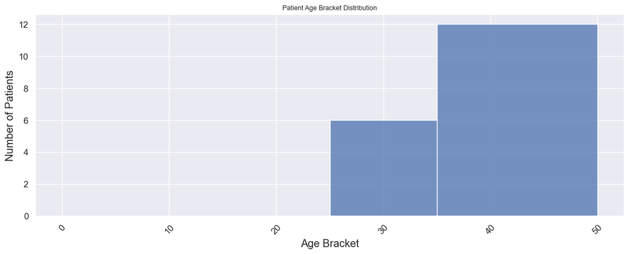

```python
fig, ax = plt.subplots(figsize=(12,5))

sns.histplot(x=df.PatientAge, data=df, bins=age_bins, palette="Blues")

plt.title("Patient Age Bracket Distribution")
plt.xlabel("Age Bracket")
plt.ylabel("Number of Patients")
plt.xticks(rotation=45)
plt.tight_layout()
plt.show()


plt.show()
```

```python
df.head(1)
```

|  | PatientID | PatientName | Email | DateOfBirth | AccountID | AccountType | BranchCode | Location | RegistrationDate | OutstandingBalance | PatientAge | BalanceCategory | HasAppointment | AgeBracket |
| --- | --- | --- | --- | --- | --- | --- | --- | --- | --- | --- | --- | --- | --- | --- |
| 0 | 101 | Alice Johnson | alice.j@example.com | 1990-05-21 | ACCT-10002345 | Individual | BR001 | United States | 1/15/2020 | 12000 | 35.00 | High Balance | True | 26–35 |

```python
# Group by AgeBracket and count PatientID
age_summary = df.groupby("AgeBracket")["PatientID"].count().reset_index()

# Rename for clarity
age_summary.columns = ["AgeGroup", "PatientCount"]
```

```python
age_summary
```

|  | AgeGroup | PatientCount |
| --- | --- | --- |
| 0 | Under 18 | 0 |
| 1 | 18–25 | 0 |
| 2 | 26–35 | 8 |
| 3 | 36–50 | 10 |
| 4 | 51+ | 0 |

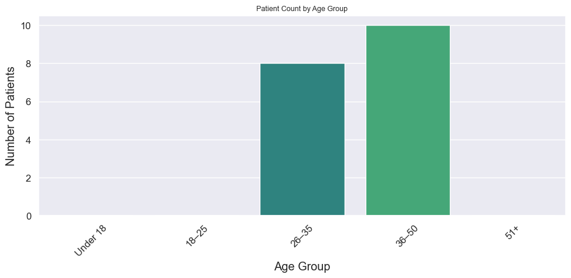

```python
# Set up plot
plt.figure(figsize=(10, 5))
sns.barplot(x="AgeGroup", y="PatientCount", data=age_summary, palette="viridis")

# Add labels and title
plt.title("Patient Count by Age Group")
plt.xlabel("Age Group")
plt.ylabel("Number of Patients")
plt.xticks(rotation=45)
plt.tight_layout()
plt.show()
```

```python
df.columns
```

```
Index(['PatientID', 'PatientName', 'Email', 'DateOfBirth', 'AccountID', 'AccountType', 'BranchCode', 'Location', 'RegistrationDate', 'OutstandingBalance', 'PatientAge', 'BalanceCategory', 'HasAppointment', 'AgeBracket'], dtype='object')
```

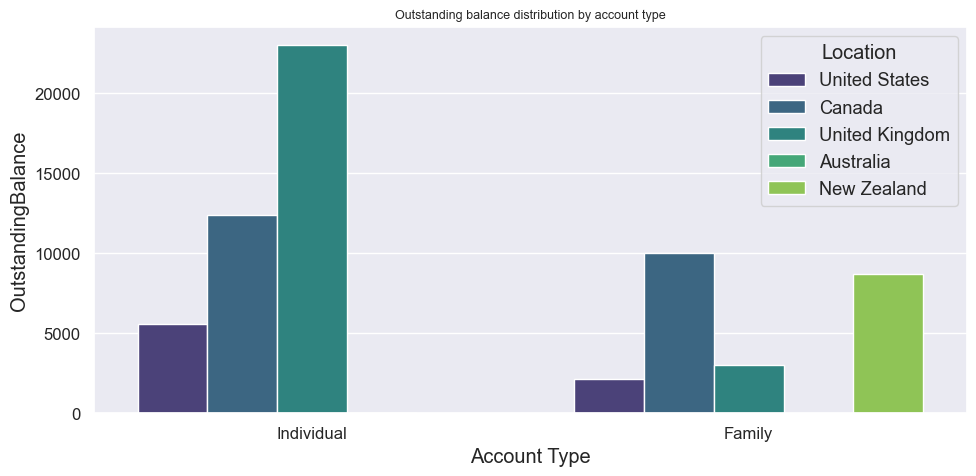

```python
# Set up plot
plt.figure(figsize=(10, 5))
sns.barplot(x="AccountType", y="OutstandingBalance", data=df, palette="viridis", hue="Location", ci=None)

# Add labels and title
plt.title("Outstanding balance distribution by account type")
plt.xlabel("Account Type")
plt.ylabel("OutstandingBalance")
plt.xticks(rotation=0)
plt.tight_layout()
plt.show()
```

```python
# Group by Location and count PatientID
location_summary = df.groupby("Location")["PatientID"].count().reset_index()

# Rename columns for clarity
location_summary.columns = ["Location", "PatientCount"]
```

```python
location_summary
```

|  | Location | PatientCount |
| --- | --- | --- |
| 0 | Australia | 1 |
| 1 | Canada | 4 |
| 2 | New Zealand | 1 |
| 3 | United Kingdom | 3 |
| 4 | United States | 11 |

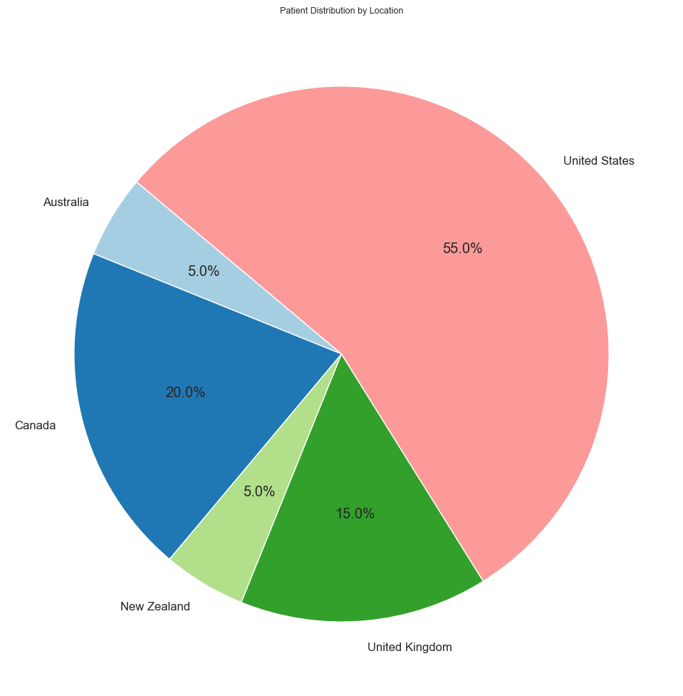

```python
# Set up pie chart
plt.figure(figsize=(10, 10))
plt.pie(
    location_summary["PatientCount"],
    labels=location_summary["Location"],
    autopct="%1.1f%%",
    startangle=140,
    colors=plt.cm.Paired.colors
)

# Add title
plt.title("Patient Distribution by Location")
plt.tight_layout()
plt.show()
```

```python
df2.head()
```

|  | AppointmentID | AccountID | AppointmentDate | AppointmentType | AppointmentFee | ClinicLocation | AppointmentMonth | FeeFlagHigh | FeeFlagNegative |
| --- | --- | --- | --- | --- | --- | --- | --- | --- | --- |
| 0 | 201 | ACCT-10002345 | 2022-01-05 | Consultation | 500 | New York | January | False | False |
| 1 | 202 | ACCT-10005678 | 2022-02-15 | Follow-up | 200 | New York | February | False | False |
| 2 | 203 | ACCT-10007891 | 2025-09-05 | Consultation | 300 | Los Angeles | September | False | False |
| 3 | 204 | ACCT-10001234 | 2022-04-10 | Follow-up | 0 | Cincinnati | April | False | False |
| 4 | 205 | ACCT-10003456 | 2022-04-30 | Consultation | 450 | San Francisco | April | False | False |

```python
df2.info()
```

```
<class 'pandas.core.frame.DataFrame'>
RangeIndex: 20 entries, 0 to 19
Data columns (total 9 columns):
 #   Column            Non-Null Count  Dtype
---  ------            --------------  -----
 0   AppointmentID     20 non-null     int64
 1   AccountID         20 non-null     object
 2   AppointmentDate   20 non-null     datetime64[ns]
 3   AppointmentType   20 non-null     object
 4   AppointmentFee    20 non-null     int64
 5   ClinicLocation    20 non-null     object
 6   AppointmentMonth  20 non-null     object
 7   FeeFlagHigh       20 non-null     bool
 8   FeeFlagNegative   20 non-null     bool
dtypes: bool(2), datetime64[ns](1), int64(2), object(4)
memory usage: 1.3+ KB
```

```python
# Group by AppointmentMonth and count AppointmentID
monthly_volume = df2.groupby("AppointmentMonth")["AppointmentID"].count().reset_index()

# Rename columns for clarity
monthly_volume.columns = ["AppointmentMonth", "AppointmentCount"]

monthly_volume
```

|  | AppointmentMonth | AppointmentCount |
| --- | --- | --- |
| 0 | April | 3 |
| 1 | August | 1 |
| 2 | February | 2 |
| 3 | January | 2 |
| 4 | July | 2 |
| 5 | June | 2 |
| 6 | March | 1 |
| 7 | May | 2 |
| 8 | November | 1 |
| 9 | October | 1 |
| 10 | September | 3 |

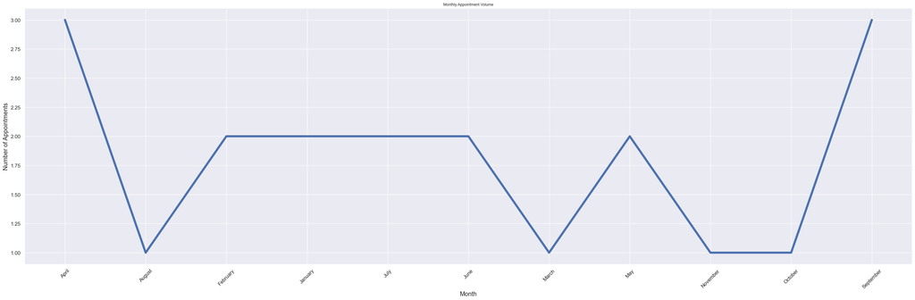

```python
fig = plt.figure(figsize=(30,10))
sns.lineplot(x="AppointmentMonth",y="AppointmentCount",data=monthly_volume, estimator=None, linewidth=5)
plt.title("Monthly Appointment Volume")
plt.xlabel("Month")
plt.ylabel("Number of Appointments")
plt.xticks(rotation=45)
plt.tight_layout()
plt.show()
```

```python
# Group by AppointmentType and count AppointmentID
type_summary = df2.groupby("AppointmentType")["AppointmentID"].count().reset_index()

# Rename for clarity
type_summary.columns = ["AppointmentType", "AppointmentCount"]

type_summary
```

|  | AppointmentType | AppointmentCount |
| --- | --- | --- |
| 0 | Consultation | 11 |
| 1 | Follow-up | 9 |

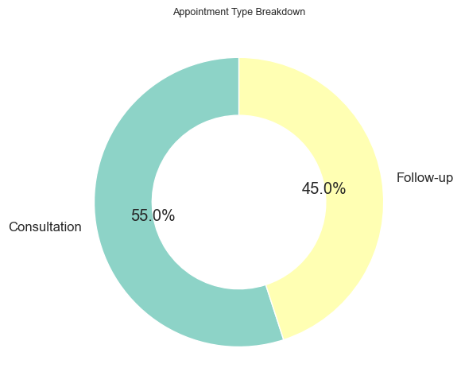

```python
# Set up pie chart with a donut hole
plt.figure(figsize=(6, 6))
wedges, texts, autotexts = plt.pie(
    type_summary["AppointmentCount"],
    labels=type_summary["AppointmentType"],
    autopct="%1.1f%%",
    startangle=90,
    wedgeprops=dict(width=0.4),  # This creates the donut effect
    colors=plt.cm.Set3.colors
)

# Add title
plt.title("Appointment Type Breakdown")
plt.tight_layout()
plt.show()
```

```python
# Group by AppointmentMonth and calculate average fee
monthly_avg_fee = df2.groupby("AppointmentMonth")["AppointmentFee"].mean().reset_index()

# Rename columns for clarity
monthly_avg_fee.columns = ["AppointmentMonth", "AverageFee"]

monthly_avg_fee
```

|  | AppointmentMonth | AverageFee |
| --- | --- | --- |
| 0 | April | 416.67 |
| 1 | August | 600.00 |
| 2 | February | 100.00 |
| 3 | January | 750.00 |
| 4 | July | 400.00 |
| 5 | June | 550.00 |
| 6 | March | 500.00 |
| 7 | May | 400.00 |
| 8 | November | 100.00 |
| 9 | October | 400.00 |
| 10 | September | 183.33 |

```python
month_order = ["January", "February", "March", "April", "May", "June", "July",
               "August", "September", "October", "November", "December"]

monthly_avg_fee["AppointmentMonth"] = pd.Categorical(monthly_avg_fee["AppointmentMonth"], categories=month_order, ordered=True)
monthly_avg_fee = monthly_avg_fee.sort_values("AppointmentMonth")
```

```python
monthly_avg_fee
```

|  | AppointmentMonth | AverageFee |
| --- | --- | --- |
| 3 | January | 750.00 |
| 2 | February | 100.00 |
| 6 | March | 500.00 |
| 0 | April | 416.67 |
| 7 | May | 400.00 |
| 5 | June | 550.00 |
| 4 | July | 400.00 |
| 1 | August | 600.00 |
| 10 | September | 183.33 |
| 9 | October | 400.00 |
| 8 | November | 100.00 |

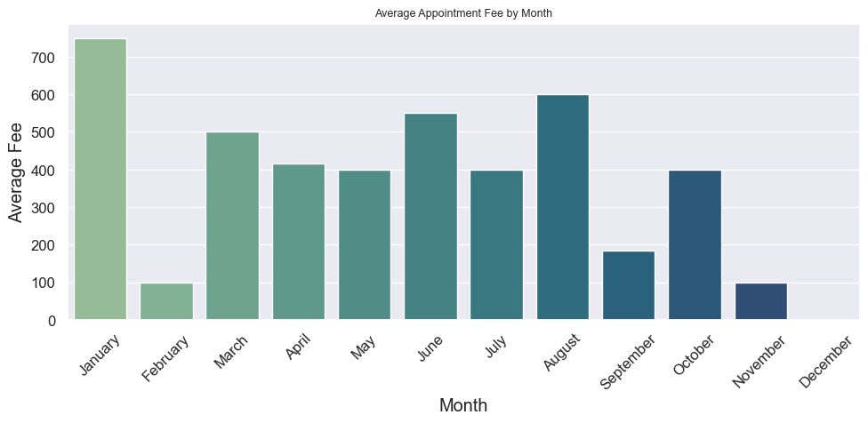

```python
plt.figure(figsize=(10, 5))
sns.barplot(x="AppointmentMonth", y="AverageFee", data=monthly_avg_fee, palette="crest")

plt.title("Average Appointment Fee by Month")
plt.xlabel("Month")
plt.ylabel("Average Fee")
plt.xticks(rotation=45)
plt.tight_layout()
plt.show()
```

**==========================================================**

## Plotly Express Graphs

```python
df2.columns
```

```
Index(['AppointmentID', 'AccountID', 'AppointmentDate', 'AppointmentType', 'AppointmentFee', 'ClinicLocation', 'AppointmentMonth', 'FeeFlagHigh', 'FeeFlagNegative'], dtype='object')
```

```python
# Group by AppointmentMonth and count appointments
monthly_volume = df2.groupby("AppointmentMonth")["AppointmentID"].count().reset_index()
monthly_volume.columns = ["AppointmentMonth", "AppointmentCount"]

monthly_volume
```

|  | AppointmentMonth | AppointmentCount |
| --- | --- | --- |
| 0 | April | 3 |
| 1 | August | 1 |
| 2 | February | 2 |
| 3 | January | 2 |
| 4 | July | 2 |
| 5 | June | 2 |
| 6 | March | 1 |
| 7 | May | 2 |
| 8 | November | 1 |
| 9 | October | 1 |
| 10 | September | 3 |

```python
fig = px.line(data_frame=monthly_volume, x="AppointmentMonth",
    y="AppointmentCount", title="Monthly Appointment Volume", markers=True,
    line_shape="linear")

fig.show()
```

[interactive chart not shown]

```python
# Group by AppointmentType and count AppointmentID
type_summary = df2.groupby("AppointmentType")["AppointmentID"].count().reset_index()

# Rename for clarity
type_summary.columns = ["AppointmentType", "AppointmentCount"]
type_summary
```

|  | AppointmentType | AppointmentCount |
| --- | --- | --- |
| 0 | Consultation | 11 |
| 1 | Follow-up | 9 |

```python
fig = px.pie(data_frame=type_summary, names="AppointmentType", values="AppointmentCount",
             width=600, height=400, title="Appointment Type Breakdown", hole=0.3)


fig.update_traces(textposition="inside", textinfo="percent+label")
fig.update_layout(template="plotly_white")
fig.show()
```

[interactive chart not shown]

```python
# Group by Location and count appointments
location_counts = df2.groupby("ClinicLocation")["AppointmentID"].count().reset_index()
location_counts.columns = ["Location", "AppointmentCount"]
location_counts
```

|  | Location | AppointmentCount |
| --- | --- | --- |
| 0 | Cincinnati | 2 |
| 1 | Dallas | 4 |
| 2 | Los Angeles | 2 |
| 3 | New York | 6 |
| 4 | San Francisco | 5 |
| 5 | Texas | 1 |

```python
fig = px.scatter_geo(
    location_counts,
    locationmode="USA-states",  # Works for city names too
    scope="usa",
    locations="Location",
    color="AppointmentCount",
    hover_name="Location",
    size="AppointmentCount",
    title="Location Wise Appointment Count",
    color_continuous_scale="Blues"
)

fig.update_layout(template="plotly_white")
fig.show()
```

[interactive chart not shown]

```python
df.head()
```

|  | PatientID | PatientName | Email | DateOfBirth | AccountID | AccountType | BranchCode | Location | RegistrationDate | OutstandingBalance | PatientAge | BalanceCategory | HasAppointment | AgeBracket |
| --- | --- | --- | --- | --- | --- | --- | --- | --- | --- | --- | --- | --- | --- | --- |
| 0 | 101 | Alice Johnson | alice.j@example.com | 1990-05-21 | ACCT-10002345 | Individual | BR001 | United States | 1/15/2020 | 12000 | 35.00 | High Balance | True | 26–35 |
| 1 | 102 | Bob Smith | bob.smith@xyz.com | 1985-08-15 | ACCT-10005678 | Family | BR002 | United States | 11/30/2019 | 3000 | 40.00 | High Balance | True | 36–50 |
| 2 | 103 | Cathy Davis | cathy.davis@example.com | 1992-11-03 | ACCT-10007891 | Individual | BR003 | United States | 6/1/2021 | 8500 | 32.00 | High Balance | True | 26–35 |
| 3 | 104 | David Lee | david.l@xyz.com | 1978-02-28 | ACCT-10001234 | Individual | BR004 | United States | 3/20/2021 | 5000 | 47.00 | High Balance | True | 36–50 |
| 4 | 105 | Eva Turner | No Email Provided | 1989-04-07 | ACCT-10003456 | Family | BR005 | United States | 7/19/2020 | 0 | 36.00 | Low Balance | True | 36–50 |

```python
df["BranchCode"].value_counts()
```

```
BranchCode
BR001    1
BR002    1
BR019    1
BR018    1
BR017    1
BR016    1
BR015    1
BR014    1
BR013    1
BR012    1
BR011    1
BR010    1
BR009    1
BR008    1
BR007    1
BR006    1
BR005    1
BR004    1
BR003    1
BR020    1
Name: count, dtype: int64
```

#### Python code done by Dennis Lam